# Team Project 2

```r
#unique(loan$loan_status)

table(loan$loan_status)
```

```
##
##                                         Charged Off
##                                              211323
##                                             Current
##                                              736187
##                                             Default
##                                                  26
## Does not meet the credit policy. Status:Charged Off
##                                                   0
##  Does not meet the credit policy. Status:Fully Paid
##                                                   0
##                                          Fully Paid
##                                              817669
##                                     In Grace Period
##                                                7322
##                                   Late (16-30 days)
##                                                3037
##                                  Late (31-120 days)
##                                               17826
```

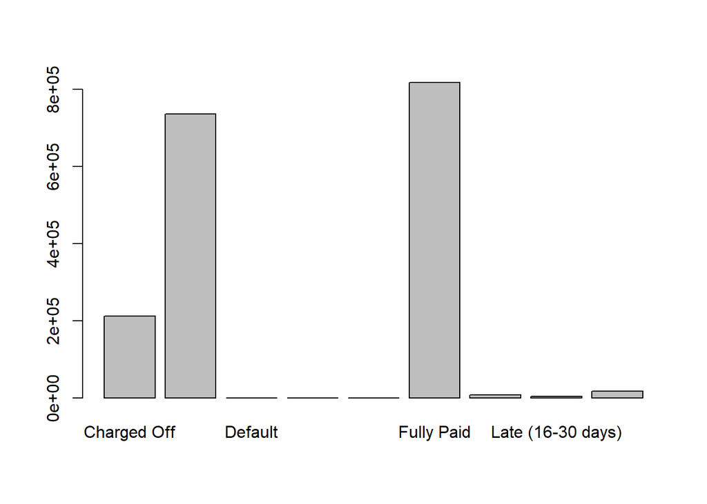

```r
barplot(table(loan$loan_status))
```

```r
loan$target <- as.factor(ifelse(loan$loan_status %in% c("Charged Off",
                    "Default",
                    "Does not meet the credit policy. Status:Charged Off",
                    "In Grace Period",
                    "Default Receiver",
                    "Late (16-30 days)",
                    "Late (31-120 days)"), 0, ifelse(loan$loan_status %in% c("Fully Paid"), 1, 2)))
table(loan$target)
```

```
##
##      0      1      2
## 239534 817669 736187
```

### filter out loans that are still “current”, which corresponds to target = 2

```r
cleaned_loan <- loan %>% filter(target != 2)
table(cleaned_loan$target)
```

```
##
##      0      1      2
## 239534 817669      0
```

### test the baseline of predicting all 1 and using the provided grade column

```r
cleaned_loan$target <- factor(cleaned_loan$target)
(baseline_grade <- table(cleaned_loan$grade, cleaned_loan$target))
```

```
##
##          0      1
##   A  11995 158640
##   B  45724 256344
##   C  77727 230810
##   D  54758 108770
##   E  32174  45319
##   F  12901  14047
##   G   4255   3739
```

```r
(all_1_acc <- nrow(cleaned_loan[which(as.integer(cleaned_loan$target) != 1),])/nrow(cleaned_loan))
```

```
## [1] 0.7734267
```

```r
(all_1_type2err <- 1)
```

```
## [1] 1
```

```r
(grade_acc <- sum(baseline_grade[c("A", "B", "C"),2])/sum(baseline_grade))
```

```
## [1] 0.6108515
```

```r
(grade_type2err <- sum(baseline_grade[c("D", "E", "F", "G"), 1])/sum(baseline_grade[, 1]))
```

```
## [1] 0.4345437
```

Predicting all 1 results in an accuracy of 0.7734 and a Type 2 error of 1. We cannot predict any of the default.  
Using the provided grade column as indicator we manage to get a accuracy of 0.61 while predicting 43% out of all defaults. Noted that we can change the threshold for grade to adjust the trade-off.

Our purpose is to develop a model that can minimize type 2 error, which in other words mean we want to be able to predict as many bad loans as possible, while maintaing a resonable level of accuracy.

Now we proceed to filter out variables that are unsuable such as the employee title because everyone has his or her own unique employee title, and hardship-related variables since there is no way we would know those when the loan originates.

```r
colnames(cleaned_loan)
```

```
##   [1] "loan_amnt"                  "funded_amnt"
##   [3] "funded_amnt_inv"            "term"
##   [5] "int_rate"                   "installment"
##   [7] "grade"                      "sub_grade"
##   [9] "emp_title"                  "emp_length"
##  [11] "home_ownership"             "annual_inc"
##  [13] "verification_status"        "issue_d"
##  [15] "loan_status"                "pymnt_plan"
##  [17] "desc"                       "purpose"
##  [19] "title"                      "zip_code"
##  [21] "addr_state"                 "dti"
##  [23] "delinq_2yrs"                "earliest_cr_line"
##  [25] "inq_last_6mths"             "open_acc"
##  [27] "pub_rec"                    "revol_bal"
##  [29] "revol_util"                 "total_acc"
```

[output cut: 36 more lines]

```r
usable_variables <- c("loan_amnt", "funded_amnt", "term", "int_rate", "installment", "emp_length", "home_ownership",
                        "annual_inc", "verification_status", "pymnt_plan", "purpose", "dti", "delinq_2yrs",
                        "inq_last_6mths", "open_acc", "pub_rec", "revol_bal", "revol_util", "total_acc",
                        "initial_list_status", "tot_coll_amt", "acc_now_delinq", "delinq_amnt", "tot_cur_bal",
                        "avg_cur_bal", "collections_12_mths_ex_med", "chargeoff_within_12_mths", "bc_open_to_buy",
                        "bc_util", "acc_open_past_24mths", "mo_sin_old_il_acct", "mo_sin_old_rev_tl_op",
                        "mo_sin_rcnt_rev_tl_op", "mo_sin_rcnt_tl", "mths_since_recent_bc", "mths_since_recent_inq",
                        "num_accts_ever_120_pd", "num_actv_bc_tl", "num_actv_rev_tl", "num_bc_sats", "num_bc_tl",
                        "num_il_tl", "num_op_rev_tl", "num_rev_accts", "num_rev_tl_bal_gt_0", "num_sats",
                        "num_tl_120dpd_2m", "num_tl_30dpd", "num_tl_90g_dpd_24m", "num_tl_op_past_12m", "pct_tl_nvr_dlq",
                        "percent_bc_gt_75", "pub_rec_bankruptcies", "tax_liens", "tot_hi_cred_lim", "total_bal_ex_mort",
                        "total_bc_limit", "total_il_high_credit_limit", "disbursement_method", "target")

cleaned_loan_2 <- cleaned_loan[,colnames(cleaned_loan) %in% usable_variables]
```

```r
head(cleaned_loan_2)
```

```
##   loan_amnt funded_amnt       term int_rate installment emp_length
## 1     30000       30000  36 months    22.35     1151.16    5 years
## 2     40000       40000  60 months    16.14      975.71   < 1 year
## 3     20000       20000  36 months     7.56      622.68  10+ years
## 4      4500        4500  36 months    11.31      147.99  10+ years
## 5      8425        8425  36 months    27.27      345.18    3 years
## 6     20000       20000  60 months    17.97      507.55    4 years
##   home_ownership annual_inc verification_status pymnt_plan
## 1       MORTGAGE     100000     Source Verified          n
## 2       MORTGAGE      45000            Verified          n
## 3       MORTGAGE     100000        Not Verified          n
## 4           RENT      38500        Not Verified          n
## 5       MORTGAGE     450000            Verified          n
## 6           RENT      57000        Not Verified          n
##              purpose   dti delinq_2yrs inq_last_6mths open_acc pub_rec
```

[output cut: 90 more lines]

### export the cleaned version of our data to a csv file and run model on it.

```r
write.csv(cleaned_loan_2, "cleaned_loan.csv")
```